# Lab 6

Griffin Shelor

10/05/2023

## Question 1

A survey for desert tortoises over an area in Southern Nevada yielded point observations of presence/absence data for the species. Some people have suggested that desert tortoise population densities may vary by elevation. A) Use the PER.shp file (which contains points where positive encounters were recorded) to check CSR (are they distributed randomly?). If so (if the points are clustered) create a ppm of the density of survey points with encounters relative to elevation (elev.tif). B) Plot and summarize your results. C) Do the densities of positive encounter rates appear to co-vary with elevation? D) How? (hint - Be sure to unmark() your ppp)

```r
set.seed(802)
per <- read_sf("Lab6_data/PER.shp")
crsuggest::suggest_crs(per)
```

```
## # A tibble: 10 × 6
##    crs_code crs_name                        crs_type crs_gcs crs_units crs_proj4
##    <chr>    <chr>                           <chr>      <dbl> <chr>     <chr>
##  1 6424     NAD83(2011) / California zone … project…    6318 us-ft     +proj=lc…
##  2 6423     NAD83(2011) / California zone 5 project…    6318 m         +proj=lc…
##  3 3498     NAD83(NSRS2007) / California z… project…    4759 us-ft     +proj=lc…
##  4 3497     NAD83(NSRS2007) / California z… project…    4759 m         +proj=lc…
##  5 2874     NAD83(HARN) / California zone … project…    4152 us-ft     +proj=lc…
##  6 2770     NAD83(HARN) / California zone 5 project…    4152 m         +proj=lc…
##  7 26945    NAD83 / California zone 5       project…    4269 m         +proj=lc…
##  8 2229     NAD83 / California zone 5 (ftU… project…    4269 us-ft     +proj=lc…
##  9 26745    NAD27 / California zone V       project…    4267 us-ft     +proj=lc…
## 10 6521     NAD83(2011) / Nevada East (ftU… project…    6318 us-ft     +proj=tm…
```

```r
## re reading in per as sf type but with crs from crsuggest
per <- read_sf("Lab6_data/PER.shp", crs = 6521)
```

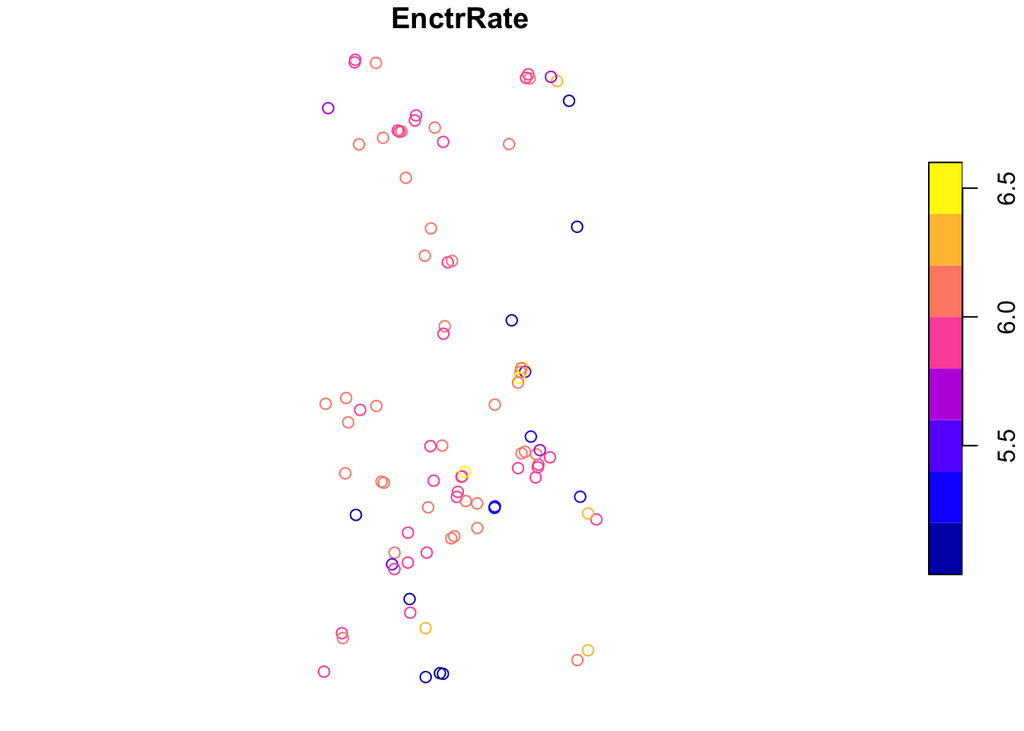

```r
per_vect <- vect(per)
plot(per)
```

```r
per_ppp <- as.ppp(per)
per_env <- envelope(per_ppp, fun = Gest, nsim = 100, savefuns = T)
```

```
## Generating 100 simulations of CSR  ...
## 1, 2, 3, 4, 5, 6, 7, 8, 9, 10, 11, 12, 13, 14, 15, 16, 17, 18, 19, 20, 21, 22, 23, 24, 25, 26, 27, 28, 29, 30, 31, 32, 33, 34, 35, 36, 37, 38, 39, 40,
## 41, 42, 43, 44, 45, 46, 47, 48, 49, 50, 51, 52, 53, 54, 55, 56, 57, 58, 59, 60, 61, 62, 63, 64, 65, 66, 67, 68, 69, 70, 71, 72, 73, 74, 75, 76, 77, 78, 79, 80,
## 81, 82, 83, 84, 85, 86, 87, 88, 89, 90, 91, 92, 93, 94, 95, 96, 97, 98, 99,  100.
##
## Done.
```

```r
mad.test(per_env)
```

```
##
##  Maximum absolute deviation test of CSR
##  Monte Carlo test based on 100 simulations
##  Summary function: G(r)
##  Reference function: theoretical
##  Alternative: two.sided
##  Interval of distance values: [0, 10671.5855386869]
##  Test statistic: Maximum absolute deviation
##  Deviation = observed minus theoretical
##
## data:  per_ppp
## mad = 0.41729, rank = 1, p-value = 0.009901
```

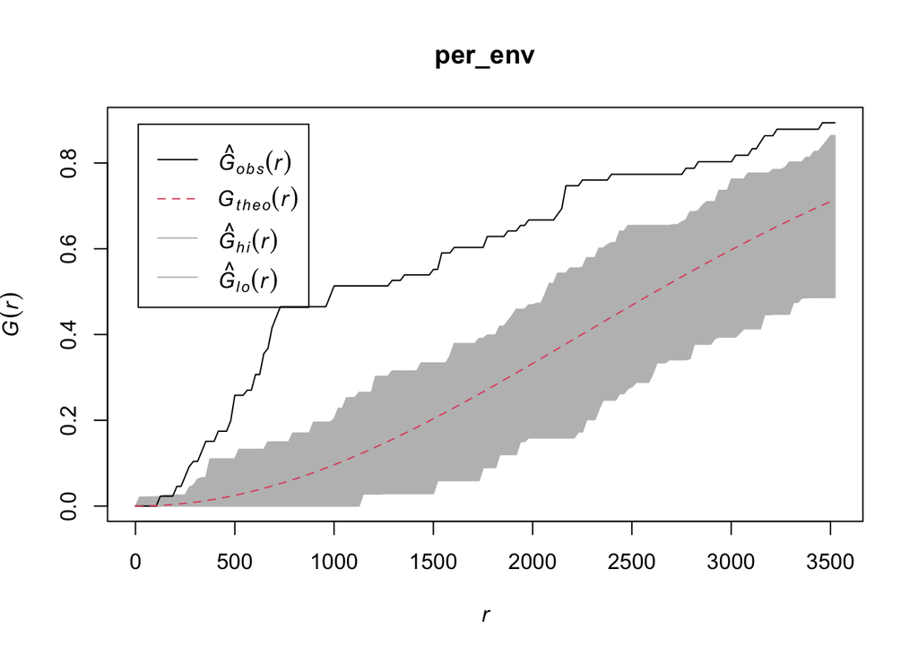

```r
plot(per_env)
```

```r
## The points are not distributed randomly. The plot of the envelope indicates that there is statistically significant clustering of the points.

## reading in tif
elevation <- rast("Lab6_data/elev.tif")
terra::project(elevation, crs(per_vect))
```

```
## class       : SpatRaster
## dimensions  : 393, 236, 1  (nrow, ncol, nlyr)
## resolution  : 817.761, 817.761  (x, y)
## extent      : 769654.2, 962645.8, 26357903, 26679283  (xmin, xmax, ymin, ymax)
## coord. ref. : NAD83(2011) / Nevada East (ftUS) (EPSG:6521)
## source(s)   : memory
## name        :      elev
## min value   :  153.0556
## max value   : 1617.2968
```

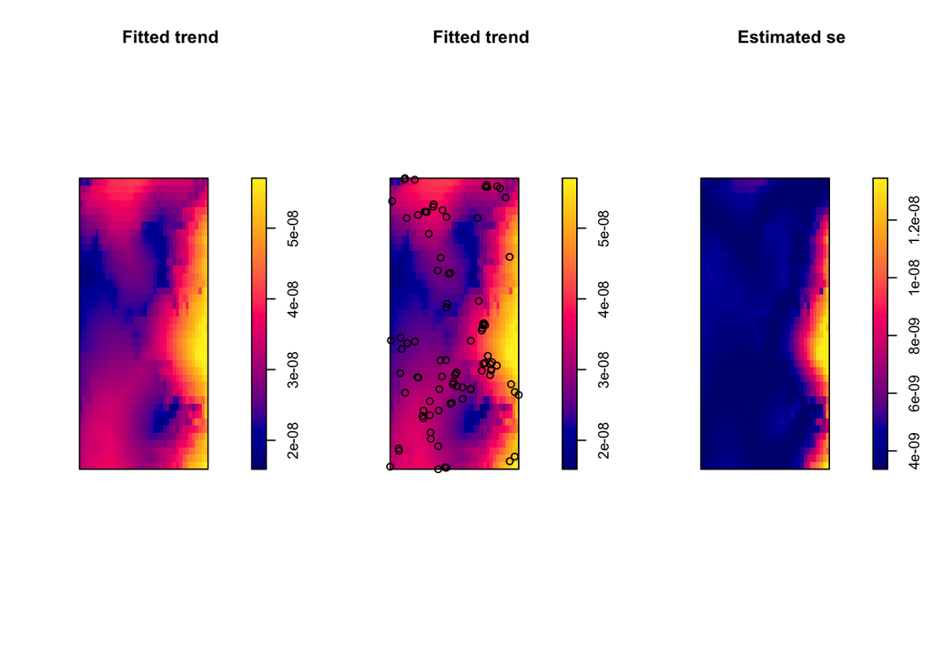

```r
elevation <- crop(elevation, per_vect)

## converting spatraster to img
elevation_img <- as.im(raster::raster(elevation))

## fitting PPM
per_ppp_unmark <- unmark(per_ppp)
per_elev_ppm <- ppm(per_ppp_unmark ~ elevation_img)
par(mfrow=c(1,3))
plot(per_elev_ppm, trend=T, superimpose= F, se=F)
plot(per_elev_ppm, trend=T, se=F)
plot(per_elev_ppm, trend=F, superimpose= F, se=T)
```

```r
#anova(per_elev_ppm, test='Chisq')
#summary(anova(per_elev_ppm, test='Chisq'))
summary(per_elev_ppm)
```

```
## Point process model
## Fitted to data: per_ppp_unmark
## Fitting method: maximum likelihood (Berman-Turner approximation)
## Model was fitted using glm()
## Algorithm converged
## Call:
## ppm.formula(Q = per_ppp_unmark ~ elevation_img)
## Edge correction: "border"
##  [border correction distance r = 0 ]
## --------------------------------------------------------------------------------
## Quadrature scheme (Berman-Turner) = data + dummy + weights
##
## Data pattern:
## Planar point pattern:  91 points
## Average intensity 3.22e-08 points per square unit
## Window: rectangle = [-1702916.7, -1667599] x [1507672, 1587742.3] units
##                     (35320 x 80070 units)
## Window area = 2827900000 square units
##
## Dummy quadrature points:
##      32 x 32 grid of dummy points, plus 4 corner points
##      dummy spacing: 1103.677 x 2502.197 units
##
## Original dummy parameters: =
## Planar point pattern:  1028 points
## Average intensity 3.64e-07 points per square unit
## Window: rectangle = [-1702916.7, -1667599] x [1507672, 1587742.3] units
##                     (35320 x 80070 units)
## Window area = 2827900000 square units
## Quadrature weights:
##      (counting weights based on 32 x 32 array of rectangular tiles)
## All weights:
##  range: [690000, 2760000]    total: 2.83e+09
## Weights on data points:
##  range: [690000, 1380000]    total: 1.1e+08
## Weights on dummy points:
##  range: [690000, 2760000]    total: 2.72e+09
## --------------------------------------------------------------------------------
## FITTED :
##
```

[output cut: 14 more lines]

```
## (Intercept)   -1.648873e+01 0.3043411197 -17.085224217 -1.589223e+01   ***
## elevation_img -9.798502e-04 0.0003845162  -0.001733488 -2.262123e-04     *
##                     Zval
## (Intercept)   -54.178438
## elevation_img  -2.548268
##
## ----------- gory details -----
##
## Fitted regular parameters (theta):
##   (Intercept) elevation_img
## -1.648873e+01 -9.798502e-04
##
## Fitted exp(theta):
##   (Intercept) elevation_img
##  6.902987e-08  9.990206e-01
```

```r
## Based on the z test value from the ppm, there does appear to be a significant relationship between elevation and encountering Desert Tortoises. While the p value indicates significance, the parameter estimate is small which may indicate a lower effect size.
## Yes, the density of positive encounter rates appear to co-vary with elevation.
## Given that the parameter estimate for elevation is negative, this implies that as elevation decreases, the probability of a positive encounter with a Desert Tortoise increases. When looking at the plots, there are more tortoise points at areas of relatively medium elevation.
```

## Question 2.

Other researchers have reported that the density of tortoise observations may be influenced by slope. A) Create another ppm this time using the slope.tif file. B) Plot and summarize your result. C) Is the influence of slope on density significant? D) If so - Which direction (positive or negative)?

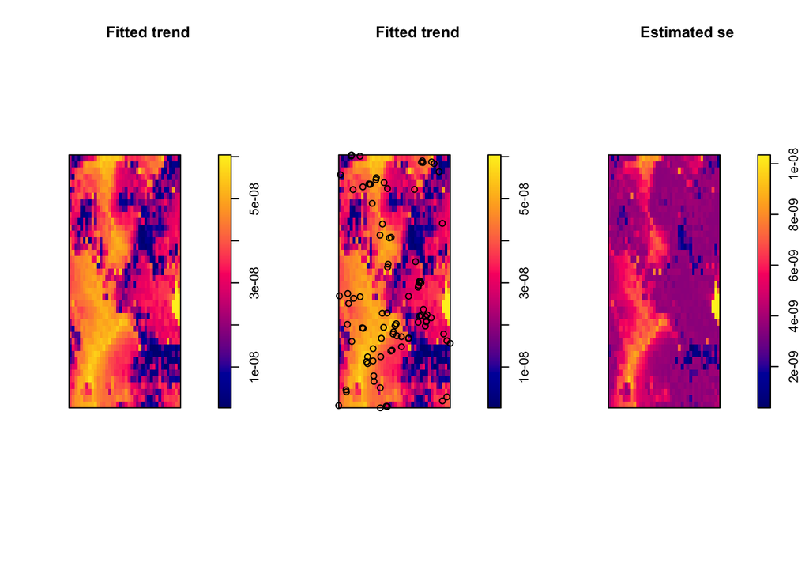

```r
slope <- rast("Lab6_data/slope.tif")
## slope <- terra::project(slope, crs(per_vect))
slope_img <- as.im(raster::raster(slope))
per_slope_ppm <- ppm(per_ppp_unmark ~ slope_img)
par(mfrow=c(1,3))
plot(per_slope_ppm, trend=T, superimpose= F, se=F)
plot(per_slope_ppm, trend=T, se=F)
plot(per_slope_ppm, trend=F, superimpose= F, se=T)
```

```r
anova(per_slope_ppm, test='Chisq')
```

```
## Analysis of Deviance Table
## Terms added sequentially (first to last)
##
##           Df Deviance Npar  Pr(>Chi)
## NULL                     1
## slope_img  1    22.68    2 1.913e-06 ***
## ---
## Signif. codes:  0 '***' 0.001 '**' 0.01 '*' 0.05 '.' 0.1 ' ' 1
```

```r
## summary(anova(per_slope_ppm, test='Chisq'))
summary(per_slope_ppm)
```

```
## Point process model
## Fitted to data: per_ppp_unmark
## Fitting method: maximum likelihood (Berman-Turner approximation)
## Model was fitted using glm()
## Algorithm converged
## Call:
## ppm.formula(Q = per_ppp_unmark ~ slope_img)
## Edge correction: "border"
##  [border correction distance r = 0 ]
## --------------------------------------------------------------------------------
## Quadrature scheme (Berman-Turner) = data + dummy + weights
##
## Data pattern:
## Planar point pattern:  91 points
## Average intensity 3.22e-08 points per square unit
## Window: rectangle = [-1702916.7, -1667599] x [1507672, 1587742.3] units
##                     (35320 x 80070 units)
## Window area = 2827900000 square units
##
## Dummy quadrature points:
##      32 x 32 grid of dummy points, plus 4 corner points
##      dummy spacing: 1103.677 x 2502.197 units
##
## Original dummy parameters: =
## Planar point pattern:  1028 points
## Average intensity 3.64e-07 points per square unit
## Window: rectangle = [-1702916.7, -1667599] x [1507672, 1587742.3] units
##                     (35320 x 80070 units)
## Window area = 2827900000 square units
## Quadrature weights:
##      (counting weights based on 32 x 32 array of rectangular tiles)
## All weights:
##  range: [690000, 2760000]    total: 2.83e+09
## Weights on data points:
##  range: [690000, 1380000]    total: 1.1e+08
## Weights on dummy points:
##  range: [690000, 2760000]    total: 2.72e+09
## --------------------------------------------------------------------------------
## FITTED :
##
```

[output cut: 11 more lines]

```
##   -16.62190    -0.22158
##
##              Estimate       S.E.     CI95.lo     CI95.hi Ztest       Zval
## (Intercept) -16.62190 0.17128888 -16.9576159 -16.2861758   *** -97.040132
## slope_img    -0.22158 0.05938816  -0.3379787  -0.1051814   ***  -3.731048
##
## ----------- gory details -----
##
## Fitted regular parameters (theta):
## (Intercept)   slope_img
##   -16.62190    -0.22158
##
## Fitted exp(theta):
##  (Intercept)    slope_img
## 6.042301e-08 8.012518e-01
```

```r
## There is a statistically significant relationship between slope and positive encounter density of Desert Tortoises. The Z test indicates a high level of significance. Based on the parameter estimates, positive encounter density of Desert Tortoises increases as slope decreases. This means it is significant in a negative direction.
```

## Question 3

Going back to your analyses in questions 1 and 2. A) Create a full model set including all combinations of elevation and slope (i.e. add Null, additive and interaction terms). B) Use AIC to determine the best model(s). C) Source (e.g. source(‘ppmaic.R’)) the file included called ppmaic.R which includes the function ppmaic(). The function takes as an argument a text array of your model names e.g. ppmaic(modelnames) will return an aic table where modelnames <- c(‘mymod1’,‘mymod2’,‘mymod3’. D) Describe the model that best describes the density of observations. E) How do you know this is the best model?

```r
per_ppm_null <- ppm(per_ppp_unmark ~ 1)
per_ppm_add <- ppm(per_ppp_unmark ~ elevation_img + slope_img)
per_ppm_int <- ppm(per_ppp_unmark ~ elevation_img * slope_img)
## calculating AIC
AIC(per_ppm_null)
```

```
## [1] 3323.853
```

```r
AIC(per_ppm_add)
```

```
## [1] 3300.609
```

```r
AIC(per_ppm_int)
```

```
## [1] 3301.652
```

```r
source("ppmaic.R")
modelnames <- c("per_elev_ppm", "per_slope_ppm", "per_ppm_null", "per_ppm_add", "per_ppm_int")
ppmaic(modelnames)
```

```
##           model  AIC  Delta          wi           W
## 4   per_ppm_add 3301  0.000 1.000000000 0.534478511
## 5   per_ppm_int 3302  1.044 0.593444089 0.317183113
## 2 per_slope_ppm 3303  2.564 0.277448916 0.148290483
## 1  per_elev_ppm 3319 18.851 0.000080642 0.000043101
## 3  per_ppm_null 3324 23.244 0.000008965 0.000004792
```

```r
## The additive model is the best model since it has the lowest AIC. However, there is not a meaningful distinction between the additive model and the interactive model since the deltaAIC is less than 2. The additive model has slightly less complexity compared to the interactive model, so I would use that model to best predict the density of Desert Tortoise observations.
```

## Question 4

1. Load the DEM for the great basin (GBMiniDem2.tif) and Weather data describing the average max temperature for the region (wx.shp). B) For points located within the great basin (as defined by the dem boundary in the DEM file), create an inverse distance weighted model of the Average Max Temperature expressed as a raster object. To achieve this you may need to specify the IDW function from the Gstat package as opposed to the spatstat package using gstat::idw(). C) Plot your result.

```r
## extract dem to weather data, convert dem to points, idw code from lecture 12
## reading in DEM
dem <- rast("Lab6_data/GBMiniDem2.tif")
dem <- terra::project(dem, "epsg:6340")
dem_vect <- as.points(dem)
dem_sf <- st_as_sf(dem_vect)
# dem_poly <- as.polygons(dem)
# dem_poly <- aggregate(dem_poly)

## reading in weather data
wx <- read_sf("Lab6_data/wx.shp")
wx <- st_transform(wx, 6340)
wx_vect <- vect(wx)
wx_vect$elev <- terra::extract(dem, wx_vect)[,2]
# wx_vect <- terra::crop(wx_vect, dem)
wx_vect <- subset(wx_vect, is.na(wx_vect$elev) ==F)
# plot(dem)
# points(wx_vect)
wx_sf <- st_as_sf(wx_vect)

## IDW model
set.seed(802)
temp_idw <- gstat::idw(AvgMxT ~ 1, wx_sf, dem_sf, idp = 2.5)
```

```
## [inverse distance weighted interpolation]
```

```r
temp_idw_vect <- vect(temp_idw)
temp_idw_rast <-  rasterize(temp_idw_vect, dem, field = 'var1.pred', touches=T, na.rm = TRUE)
terra::project(temp_idw_rast, crs(dem))
```

```
## class       : SpatRaster
## dimensions  : 1122, 1197, 1  (nrow, ncol, nlyr)
## resolution  : 959.5, 959.5  (x, y)
## extent      : -44445, 1104102, 3821152, 4897734  (xmin, xmax, ymin, ymax)
## coord. ref. : NAD83(2011) / UTM zone 11N (EPSG:6340)
## source(s)   : memory
## name        : last
## min value   :  4.1
## max value   : 49.9
```

```
## SpatRaster resampled to ncells = 500735
```

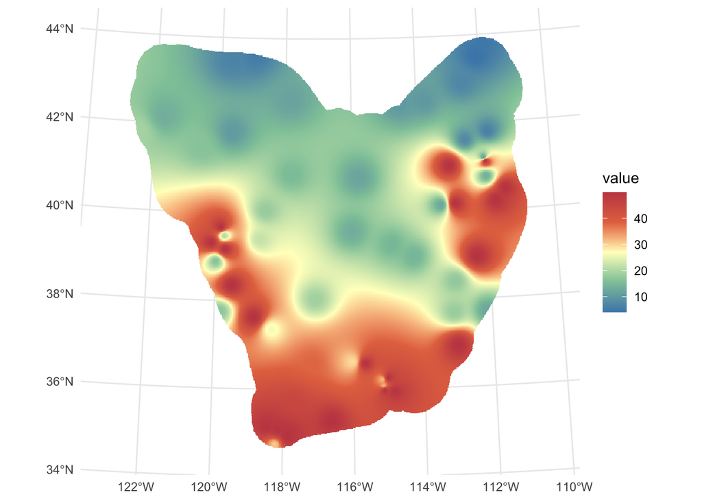

```r
# temp_idw_rast_trim <- trim(temp_idw_rast)
# temp_idw_rast_mask <- mask(temp_idw_rast_trim, dem_poly)
# temp_idw_rast <- temp_idw_rast |>
#   tidyterra::filter(!is.na(temp_idw_rast))
# temp_idw_rast <- rast(temp_idw_rast)
# ggplot() +
#   theme_minimal() +
#   geom_spatraster(data = temp_idw_rast) +
#   scale_color_viridis_c(option = "plasma", na.value = NA)
ggplot() +
  theme_minimal() +
  geom_spatraster(data = temp_idw_rast, na.rm = TRUE) +
  scale_fill_whitebox_c(palette = "muted", na.value = NA)
```

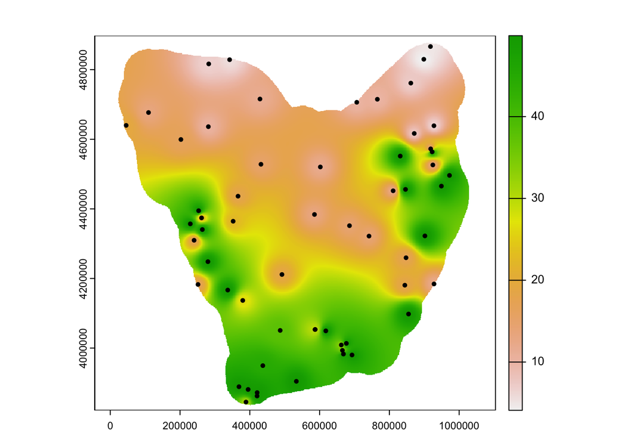

```r
plot(temp_idw_rast)
points(wx_vect)
```

## Question 5.

1. Create 1st 2nd, and 3rd order (degree) polynomial simple Kriging models of the same data from question 4. B) Plot your results. C) Compare the patterns from the kriged models with that of the idw model from question 4. D) How do they differ?

```r
temp_krig1 <- krige(AvgMxT ~ 1, wx_sf, dem_sf,  degree = 1)
```

```
## [ordinary or weighted least squares prediction]
```

```r
temp_krig2 <- krige(AvgMxT ~ 1, wx_sf, dem_sf,  degree = 2)
```

```
## [ordinary or weighted least squares prediction]
```

```r
temp_krig3 <- krige(AvgMxT ~ 1, wx_sf, dem_sf,  degree = 3)
```

```
## [ordinary or weighted least squares prediction]
```

```
## SpatRaster resampled to ncells = 500400
```

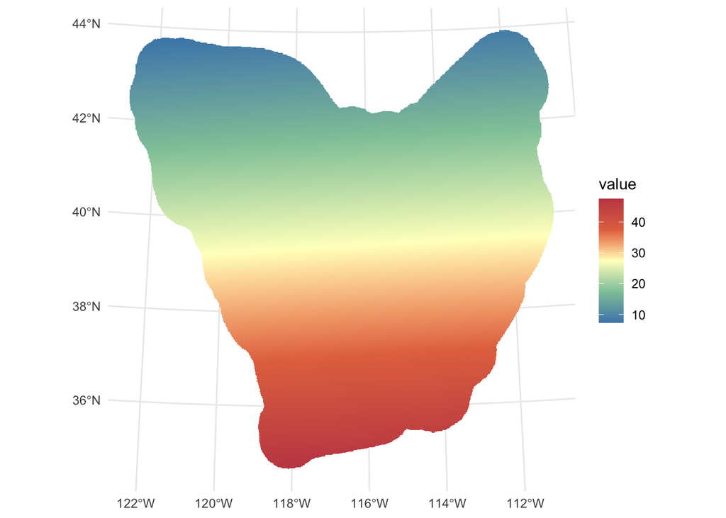

```r
temp_krig1_vect <- vect(temp_krig1)
temp_krig1_rast <-  rasterize(temp_krig1_vect, dem, field = 'var1.pred', touches=T, na.rm = TRUE)
temp_krig1_rast_trim <- trim(temp_krig1_rast)
temp_krig2_vect <- vect(temp_krig2)
temp_krig2_rast <-  rasterize(temp_krig2_vect, dem, field = 'var1.pred', touches=T, na.rm = TRUE)
temp_krig2_rast_trim <- trim(temp_krig2_rast)
temp_krig3_vect <- vect(temp_krig3)
temp_krig3_rast <-  rasterize(temp_krig3_vect, dem, field = 'var1.pred', touches=T, na.rm = TRUE)
temp_krig3_rast_trim <- trim(temp_krig3_rast)

## plotting results
ggplot() +
  theme_minimal() +
  geom_spatraster(data = temp_krig1_rast_trim, na.rm = TRUE) +
  scale_fill_whitebox_c(palette = "muted", na.value = NA)
```

```
## SpatRaster resampled to ncells = 500400
```

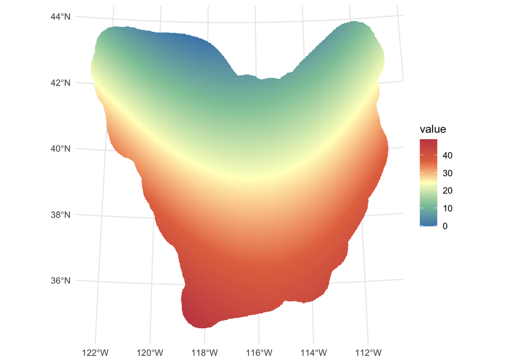

```r
# plot(temp_krig1_rast)
# points(wx_vect)
ggplot() +
  theme_minimal() +
  geom_spatraster(data = temp_krig2_rast_trim, na.rm = TRUE) +
  scale_fill_whitebox_c(palette = "muted", na.value = NA)
```

```
## SpatRaster resampled to ncells = 500400
```

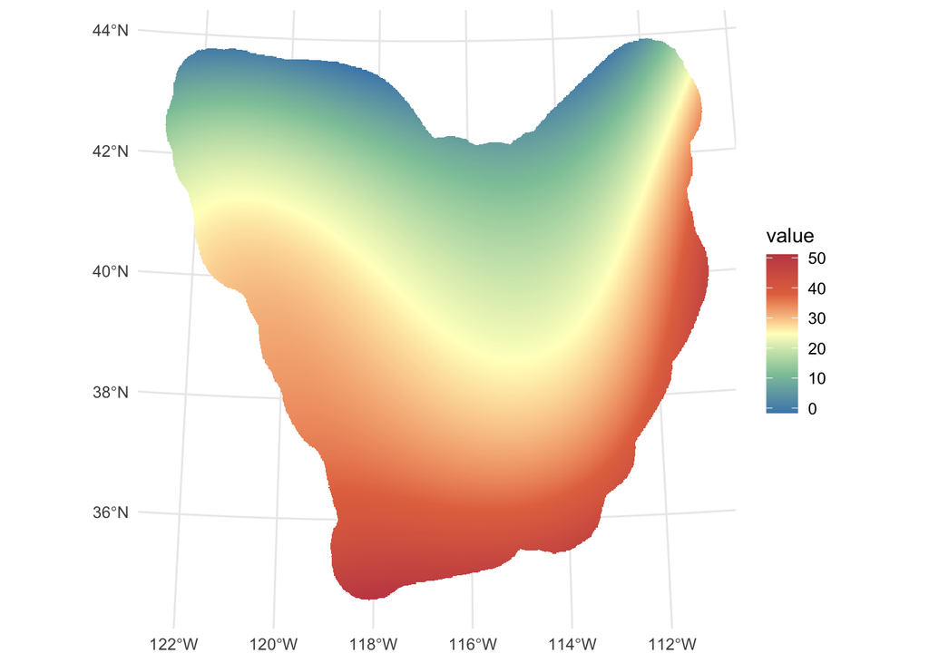

```r
# plot(temp_krig2_rast)
# points(wx_vect)
ggplot() +
  theme_minimal() +
  geom_spatraster(data = temp_krig3_rast_trim, na.rm = TRUE) +
  scale_fill_whitebox_c(palette = "muted", na.value = NA)
```

```r
# plot(temp_krig3_rast)
# points(wx_vect)

## The plots from the krige() function display a much more clearly delineated gradient than the IDW plots do, which follow the points in a much more visible way. The IDW plots show a pattern where the weather points serve as central locations with radii emanating out from those points to fill out the rest of the study area, while the kriging plots display a more continuous gradient. Because of this, it visually appears as if the IDW plots better capture variability across the landscape. They both project higher temperatures in the southern region of the study area.
```

## Question 6.(Undergrad Extra Credit - Grad students Mandatory)

Read the papers by Chen and Liu 2011, and by Nalder and Wein 1998. A) How did the approach of the IDW models they used differ? B) What are the potential benefits of the Nalder and Wein’s approach relative to the Chen and Liu approach. C) Which approach might work best in Northern Nevada? D) Why?

Answer: Nalder and Wien used 2 different methods of inverse distance in their study, in addition to multiple kriging methods. Nalder and Wien specifically used the inverse square of the distance in both of their IDW methods, while Chen and Liu tested out a variety of power levels. In the method that Nalder and Wien largely found to be most predictive and which had the least amount of error, they included the same linear regressions that they used for their detrended kriging method as coefficients for their X, Y, and elevation data. This inclusion of covariates is the biggest difference between the two papers. The potential benefits of Nalder and Wein’s approach may include less error in interpolating certain kinds of variables without having to sacrifice simplicity in their methodology. This error could potentially be further reduced by including additional variables in the regression component of their GIDS approach. Other benefits include the relative ease of interpreting the results, and the fact that it provided more consistent results than other methods. I think it is likely that Chen and Liu’s approach would work best in Nevada. Their approach of testing out different power levels in order to find a level with the lowest amount of error seems a better fit for Northern Nevada than automatically picking the inverse square of the distance. Additionally, Nalder and Wien’s approach was applied to climate stations which were described as uniform in their locations and in the characteristics of those locations. Northern Nevada has a lot of variability in its elevation and in various climatic traits such as precipitation and ratio of snowfall to rainfall. This could lead to higher error rates and instability in interpolation with methods such as the GIDS approach.